# Final Project: usaspending.gov

John Candler

DATA 2401

# Installs and libraries

```r
# Installs and libraries:
#install.packages("dbplyr")
#install.packages("RSQLite") #### for a SQLite database
#install.packages('devtools') ### IOT convert to currency
#devtools::install_github("renkun-ken/formattable") ### IOT convert to currency
#install.packages("imager")

library(tidyverse)
library(DBI)
library(dplyr)
library(dbplyr)
library(ggplot2)
library(RSQLite)
library(formattable)
library(imager)
# Prevent Scientific Notation (So you can see the big numbers)
options(scipen = 999)
```

# Before I could get started.

1. Does the Federal Government meet its contracting goals?
2. Do each of the federal agencies meet their contracting goal?
3. Which NAICS receives the most small business?
4. Which PSC receives the most small business?

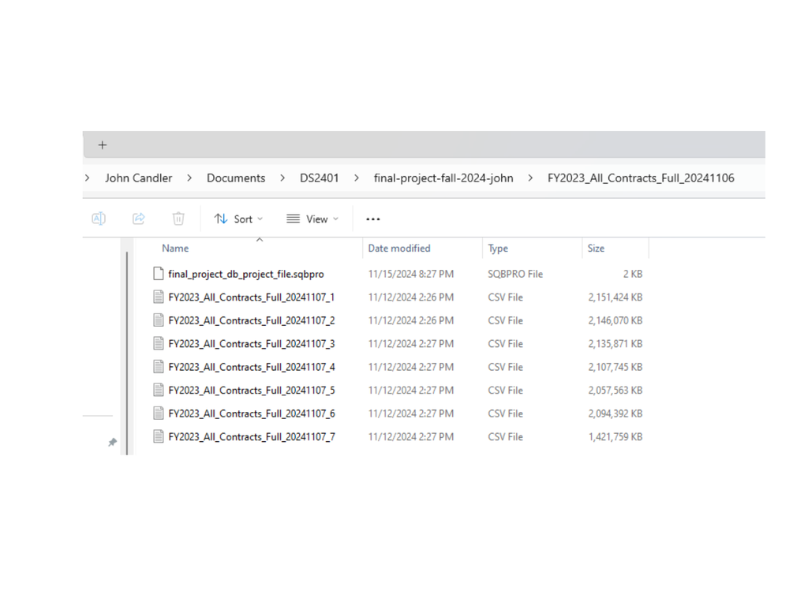

```r
im <- load.image("Screenshot (37).png")
plot(im,axes=FALSE)
```

## Script to Load data into database - Python Code

```
file_name = r"C:\Users\cjwfi\Documents\DS2401\final-project-fall-2024-john\col_names.txt"
out_file = r"C:\Users\cjwfi\Documents\DS2401\final-project-fall-2024-john\col_names_2.txt"
col_drop_file = r"C:\Users\cjwfi\Documents\DS2401\final-project-fall-2024-john\col_names_3.txt"
col_list_file = r"C:\Users\cjwfi\Documents\DS2401\final-project-fall-2024-john\col_names_4.txt"

field_int = ['action_date_fiscal_year', 'awarding_agency_code', 'recipient_zip_4_code', 'naics_code']
field_real = ['federal_action_obligation', 'total_dollars_obligated', 'base_and_all_options_value', 'potential_total_value_of_award']
primary_key = 'contract_transaction_unique_key'
main_table_name = 'FY2023_All_Contracts_Full_20241107'
table_count = 7

def field_type_dict(k:list[str]):
    ret = {}
    for s in k:
        type = 'TEXT'
        if s in field_int:
            type = 'INTEGER'
        elif s in field_real:
            type = 'REAL'
        ret[s] = type
    return ret

def write_drops(o_file, keeps, fld_types:dict):
    with open(o_file, 'w') as out_f:
        out_f.write(f'CREATE TABLE {main_table_name}(\n')
        for line in keeps:
            out_f.write(f'\t{line.strip()} {fld_types[line.strip()]},\n')
        out_f.write(f'\tPRIMARY KEY({primary_key})\n')
        out_f.write(');\n')
        for i in range(1,table_count +1):
            out_f.write(f'INSERT INTO {main_table_name} SELECT \n')
            for line in keeps:
                c = '' if line == keeps[-1] else ','
                out_f.write(f'\t{line.strip()}{c}\n')
            out_f.write(f'FROM {main_table_name}_{i};\n')
            out_f.write(f'DROP TABLE {main_table_name}_{i};\n')

def create_keep_list(file):
    keeps = []
    with open(file, 'r') as f:
        for line in f.readlines():
            keeps.append(line.strip())

    # [print(k) for k in keeps]
    return keeps


keep_list = create_keep_list(col_list_file)
field_types = field_type_dict(keep_list)
write_drops(col_drop_file, keep_list, field_types)
```

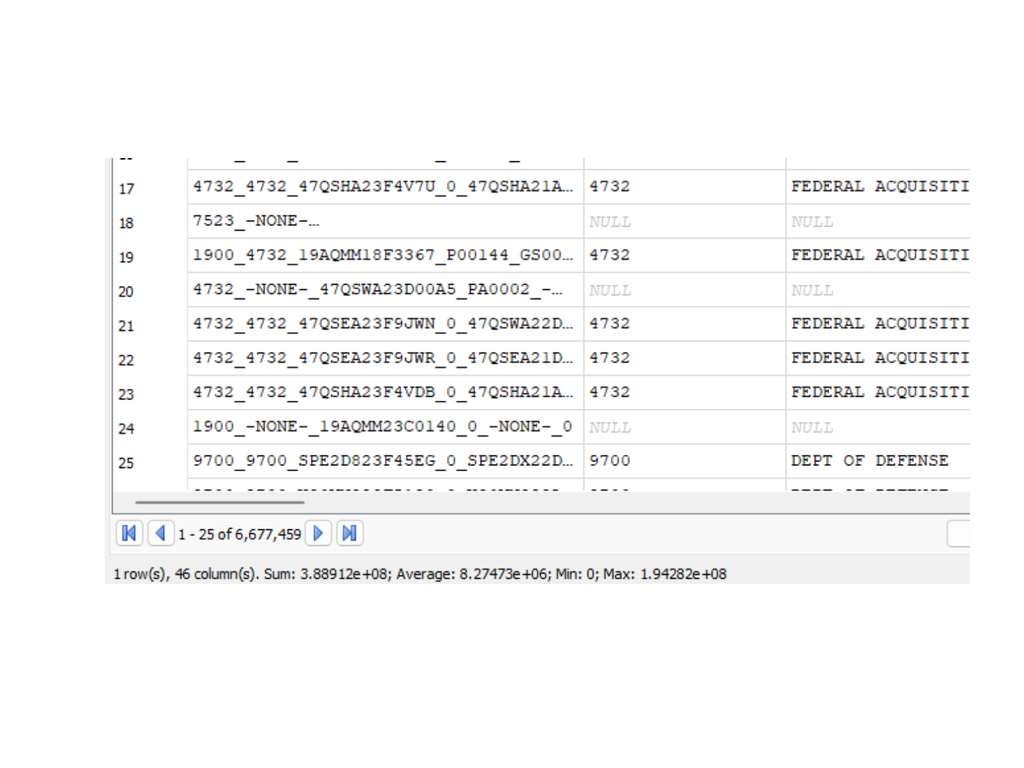

```r
im2 <- load.image("Screenshot (38).png")
plot(im2,axes=FALSE)
```

[figure not shown]

```r
im3 <- load.image("Screenshot (34).png")
plot(im3,axes=FALSE)
```

## DB Connection

```r
# Create db connection
db_connection <- dbConnect(SQLite(), dbname= 'final_project.db')
dbListTables(db_connection)
```

```
## [1] "FY2023_All_Contracts_Full_20241107"
```

```r
# Create data-frame from db table
table_fy23 <- tbl(db_connection, 'FY2023_All_Contracts_Full_20241107')
glimpse(table_fy23)
```

```
## Rows: ??
## Columns: 46
## Database: sqlite 3.46.0 [C:\Users\cjwfi\Documents\DS2401\final-project-fall-2024-john\final_project.db]
## $ contract_transaction_unique_key                          <chr> "9700_9700_SP…
## $ parent_award_agency_id                                   <chr> "9700", "9700…
## $ parent_award_agency_name                                 <chr> "DEPT OF DEFE…
## $ federal_action_obligation                                <dbl> 800.64, 10990…
## $ total_dollars_obligated                                  <dbl> 800.64, 10990…
## $ total_outlayed_amount_for_overall_award                  <chr> NA, NA, NA, N…
## $ base_and_exercised_options_value                         <chr> "800.64", "10…
## $ current_total_value_of_award                             <chr> "800.64", "10…
## $ base_and_all_options_value                               <dbl> 800.64, 10990…
## $ potential_total_value_of_award                           <dbl> 800.64, 10990…
## $ action_date                                              <chr> "2023-09-30",…
## $ action_date_fiscal_year                                  <int> 2023, 2023, 2…
```

[output cut: 34 more lines]

# FY23 Total and Percent Awarded to Small Businesses

```r
collect(table_fy23 %>% mutate(total_ob = sum(federal_action_obligation, na.rm = TRUE)) %>%
  filter(contracting_officers_determination_of_business_size == 'SMALL BUSINESS') %>%
  summarise(
    Total=max(total_ob, na.rm = TRUE),
    'Percent Awarded to Small Businesses'= sum(federal_action_obligation/total_ob, na.rm = TRUE)*100))
```

```
## # A tibble: 1 × 2
##           Total `Percent Awarded to Small Businesses`
##           <dbl>                                 <dbl>
## 1 760517183104.                                  22.7
```

# Small Business Income For FY

```r
collect(table_fy23 %>% filter(contracting_officers_determination_of_business_size == 'SMALL BUSINESS') %>%
  group_by(recipient_uei) %>%
  mutate(recipient_total = sum(federal_action_obligation, na.rm = TRUE)) %>%
  ungroup() %>%
  summarise(
    'Number of Small Businesses' = count(distinct(recipient_uei)),
    'FY Income Average'= mean(recipient_total, na.rm = T),
    'FY Income Max' = max(recipient_total, na.rm = T),
    'FY Income Min' = min(recipient_total, na.rm = T)
    ))
```

```
## # A tibble: 1 × 4
##   Number of Small Business…¹ `FY Income Average` `FY Income Max` `FY Income Min`
##                        <int>               <dbl>           <dbl>           <dbl>
## 1                      79204          200443089.     4553704183.      -91852530.
## # ℹ abbreviated name: ¹`Number of Small Businesses`
```

# Contracts Value

```r
collect(table_fy23 %>% filter(contracting_officers_determination_of_business_size == 'SMALL BUSINESS') %>%
  summarise(
    'Number of Small Businesses Contracts' = count(distinct(contract_transaction_unique_key)),
    'Contract Average Amount'= mean(federal_action_obligation, na.rm = T),
    'Amount max'= max(federal_action_obligation, na.rm = T),
    'Amount min'= min(federal_action_obligation, na.rm = T)
    ))
```

```
## # A tibble: 1 × 4
##   Number of Small Businesses …¹ Contract Average Amo…² `Amount max` `Amount min`
##                           <int>                  <dbl>        <dbl>        <dbl>
## 1                       3245667                 53132.    431007300   -81754175.
## # ℹ abbreviated names: ¹`Number of Small Businesses Contracts`,
## #   ²`Contract Average Amount`
```

# Contracts Qty

```r
collect(table_fy23 %>% filter(contracting_officers_determination_of_business_size == 'SMALL BUSINESS') %>%
  group_by(recipient_uei) %>%
  add_count(contract_transaction_unique_key) %>%
  mutate(contract_counts = sum(n, na.rm = T)) %>%
  ungroup() %>%
  summarise(
    'Number of Small Businesses Contracts' = count(distinct(contract_transaction_unique_key)),
    'Average Contacts Awarded'= mean(contract_counts, na.rm = T),
    'Awarded max'= max(contract_counts, na.rm = T),
    'Awarded min'= min(contract_counts, na.rm = T)
    ))
```

```
## # A tibble: 1 × 4
##   Number of Small Businesse…¹ Average Contacts Awa…² `Awarded max` `Awarded min`
##                         <int>                  <dbl>         <int>         <int>
## 1                     3245667                 32894.        168449             1
## # ℹ abbreviated names: ¹`Number of Small Businesses Contracts`,
## #   ²`Average Contacts Awarded`
```

# Amount to Small Businesses by Agency

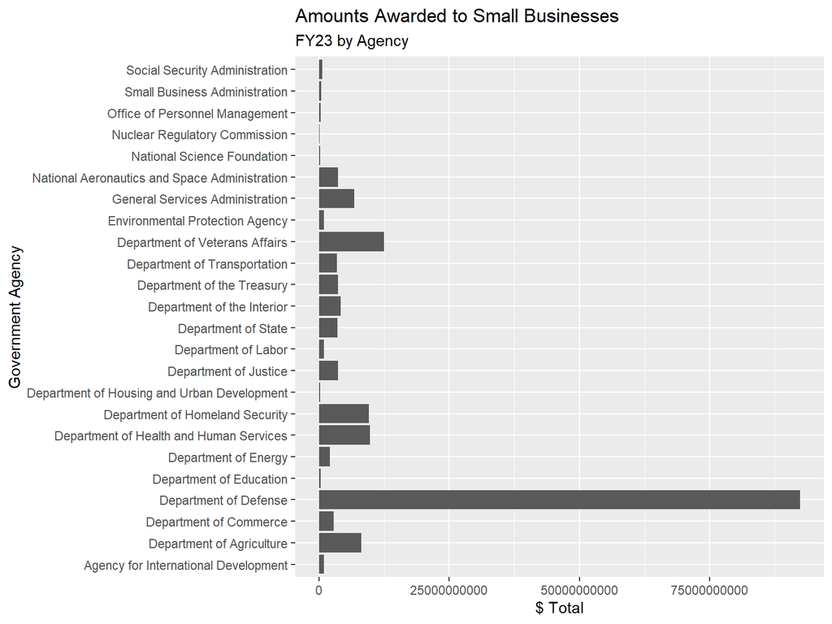

```r
#table_fy23 %>% slice_sample(n = 10000) %>%
collect(table_fy23 %>%
  filter(
    awarding_agency_name == "Department of Agriculture" |
    awarding_agency_name == "Department of Commerce" |
    awarding_agency_name == "Department of Defense" |
    awarding_agency_name == "Department of Education" |
    awarding_agency_name == "Department of Energy" |
    awarding_agency_name == "Department of Health and Human Services" |
    awarding_agency_name == "Department of Homeland Security" |
    awarding_agency_name == "Department of Housing and Urban Development" |
    awarding_agency_name == "Department of the Interior" |
    awarding_agency_name == "Department of Justice" |
    awarding_agency_name == "Department of Labor" |
    awarding_agency_name == "Department of State" |
    awarding_agency_name == "Department of Transportation" |
    awarding_agency_name == "Department of the Treasury" |
    awarding_agency_name == "Department of Veterans Affairs" |
    awarding_agency_name == "Agency for International Development" |
    awarding_agency_name == "Environmental Protection Agency" |
    awarding_agency_name == "General Services Administration" |
    awarding_agency_name == "National Aeronautics and Space Administration" |
    awarding_agency_name == "National Science Foundation" |
    awarding_agency_name == "Nuclear Regulatory Commission" |
    awarding_agency_name == "Office of Personnel Management" |
    awarding_agency_name == "Small Business Administration" |
    awarding_agency_name == "Social Security Administration"
    )) %>%
  filter(contracting_officers_determination_of_business_size == 'SMALL BUSINESS') %>%
  group_by(awarding_agency_name) %>%
  summarise(sum_money = sum(federal_action_obligation, na.rm = TRUE)) %>%
  ggplot() +
    geom_col(mapping = aes(x = sum_money, y = awarding_agency_name)) +
  labs(title = "Amounts Awarded to Small Businesses",
       subtitle = 'FY23 by Agency',
       x = "$ Total",
       y = "Government Agency")
```

## Percent Total Value to Small Businesses by Agency

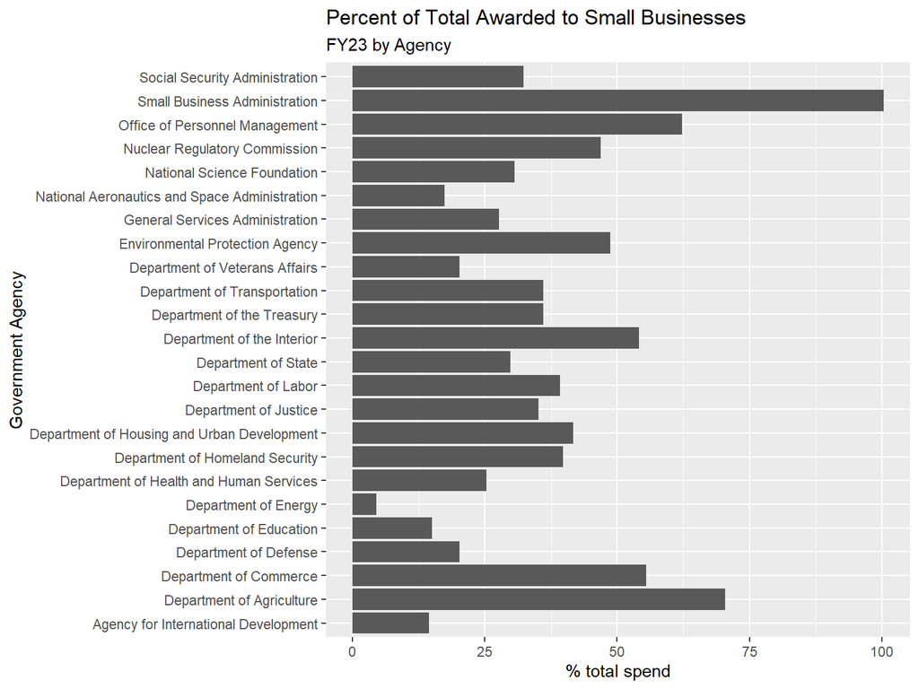

```r
#table_fy23 %>% slice_sample(n = 10000) %>%
collect(table_fy23 %>%
  filter(
    awarding_agency_name == "Department of Agriculture" |
    awarding_agency_name == "Department of Commerce" |
    awarding_agency_name == "Department of Defense" |
    awarding_agency_name == "Department of Education" |
    awarding_agency_name == "Department of Energy" |
    awarding_agency_name == "Department of Health and Human Services" |
    awarding_agency_name == "Department of Homeland Security" |
    awarding_agency_name == "Department of Housing and Urban Development" |
    awarding_agency_name == "Department of the Interior" |
    awarding_agency_name == "Department of Justice" |
    awarding_agency_name == "Department of Labor" |
    awarding_agency_name == "Department of State" |
    awarding_agency_name == "Department of Transportation" |
    awarding_agency_name == "Department of the Treasury" |
    awarding_agency_name == "Department of Veterans Affairs" |
    awarding_agency_name == "Agency for International Development" |
    awarding_agency_name == "Environmental Protection Agency" |
    awarding_agency_name == "General Services Administration" |
    awarding_agency_name == "National Aeronautics and Space Administration" |
    awarding_agency_name == "National Science Foundation" |
    awarding_agency_name == "Nuclear Regulatory Commission" |
    awarding_agency_name == "Office of Personnel Management" |
    awarding_agency_name == "Small Business Administration" |
    awarding_agency_name == "Social Security Administration"
    )) %>%
  group_by(awarding_agency_name) %>%
  mutate(agency_ob = sum(federal_action_obligation, na.rm = TRUE)) %>%
  filter(contracting_officers_determination_of_business_size == 'SMALL BUSINESS') %>%
  group_by(awarding_agency_name) %>%
  summarise(agency_mean = sum(federal_action_obligation/agency_ob, na.rm = TRUE)*100) %>%
  ggplot() +
    geom_col(mapping = aes(x = agency_mean, y = awarding_agency_name))+
  labs(title = "Percent of Total Awarded to Small Businesses",
       subtitle = 'FY23 by Agency',
       x = "% total spend",
       y = "Government Agency")
```

## Amount By NAICS

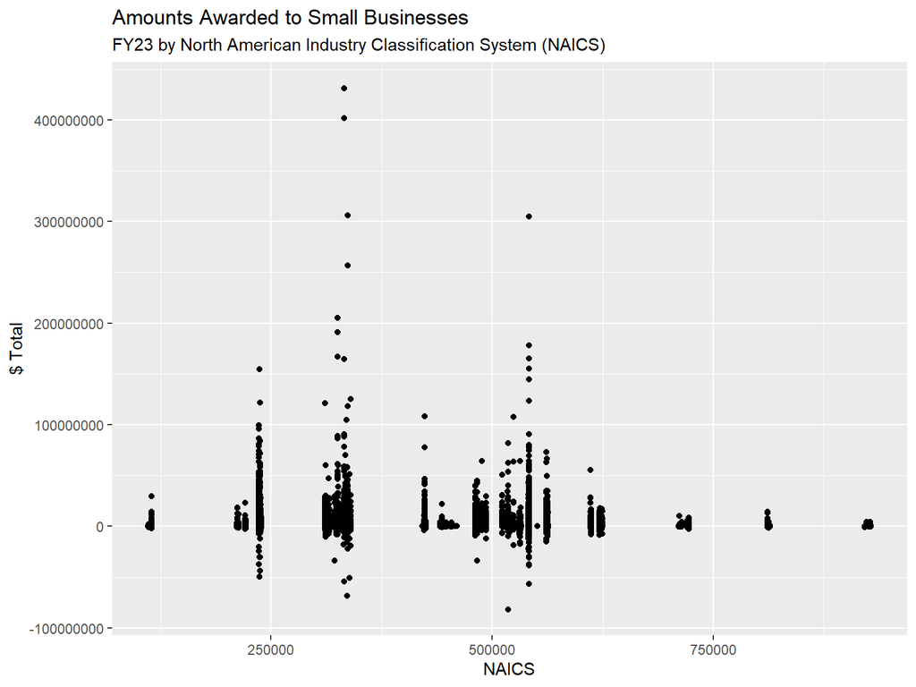

```r
collect(table_fy23 %>%
  filter(contracting_officers_determination_of_business_size == 'SMALL BUSINESS')) %>%
  group_by(naics_code) %>%
  ggplot() +
  geom_point(aes(x=naics_code, y= federal_action_obligation)) +
  labs(title = "Amounts Awarded to Small Businesses",
       subtitle = 'FY23 by North American Industry Classification System (NAICS)',
       y = "$ Total",
       x = "NAICS")
```

## Contract Qty by NAICS

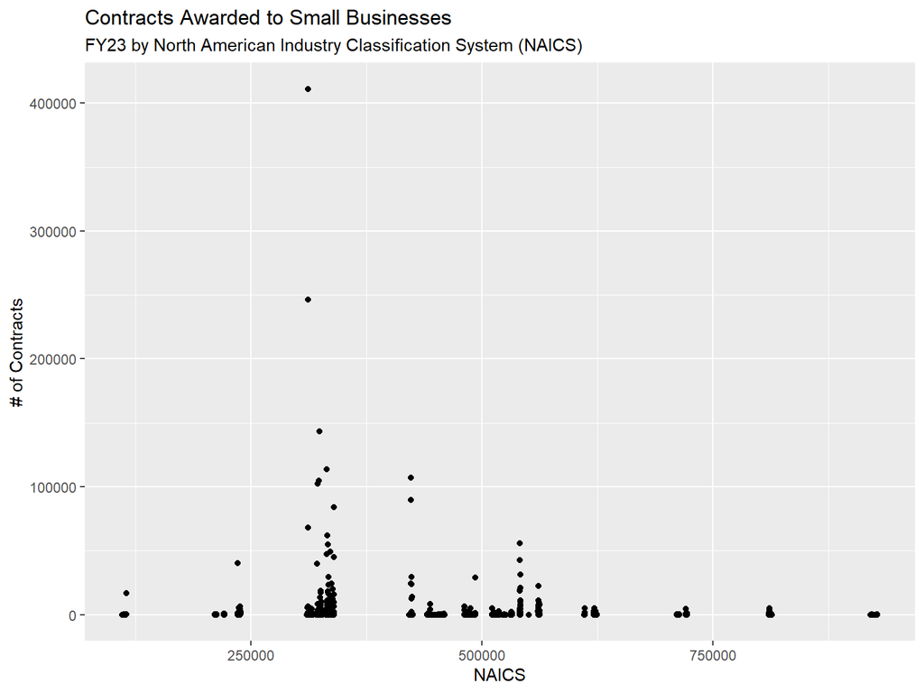

```r
collect(table_fy23 %>%
  filter(contracting_officers_determination_of_business_size == 'SMALL BUSINESS')) %>%
  group_by(naics_code) %>%
  add_count(contract_transaction_unique_key) %>%
  mutate(contract_counts = sum(n, na.rm = T)) %>%
  #ungroup() %>%
  #summarise(c_counts = max(contract_counts)) %>%
  ggplot() +
  geom_point(aes(x=naics_code, y= contract_counts)) +
  labs(title = "Contracts Awarded to Small Businesses",
       subtitle = 'FY23 by North American Industry Classification System (NAICS)',
       y = "# of Contracts",
       x = "NAICS")
```

# Contracts by NAICS Top 10

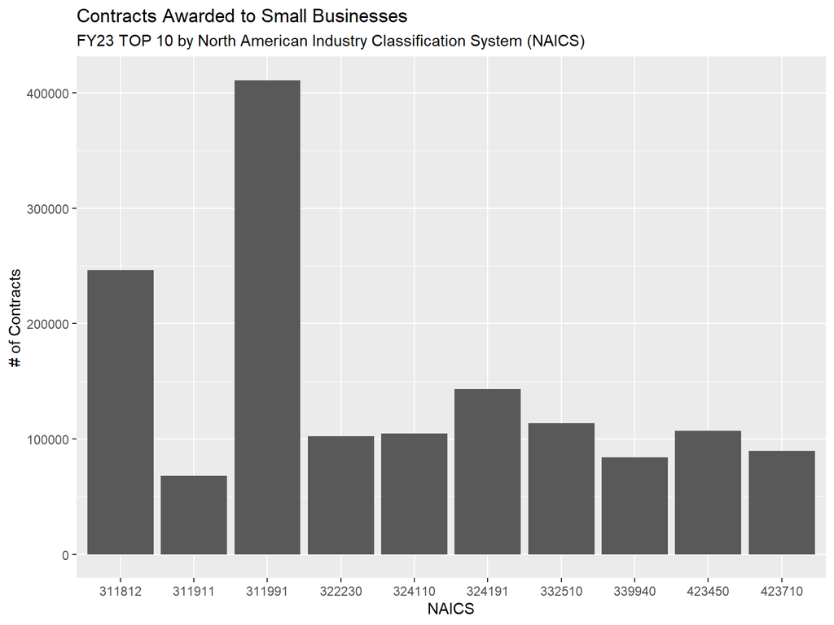

```r
collect(table_fy23 %>%
  filter(contracting_officers_determination_of_business_size == 'SMALL BUSINESS')) %>%
  mutate(naics_str = sprintf('%d',naics_code)) %>%
  group_by(naics_str) %>%
  add_count(contract_transaction_unique_key) %>%
  mutate(contract_counts = sum(n, na.rm = T)) %>%
  summarise(contracts = max(contract_counts, na.rm = T)) %>%
  arrange(desc(contracts)) %>%
  head(n=10) %>%
  ggplot() +
  geom_col(aes(x=naics_str, y=contracts)) +
  labs(title = "Contracts Awarded to Small Businesses",
       subtitle = 'FY23 TOP 10 by North American Industry Classification System (NAICS)',
       x = "NAICS",
       y = "# of Contracts")
```

311812: Commercial Bakeries 311911: Roasted Nuts and Peanut Butter Manufacturing 311991: Perishable Prepared Food Manufacturing  
322230: Stationery Product Manufacturing 324110: Petroleum Refineries 324191: Petroleum Lubricating Oil and Grease Manufacturing 332510: Hardware Manufacturing 339940: Office Supplies (except Paper) Manufacturing 423450: Medical, Dental, and Hospital Equipment and Supplies Merchant Wholesalers 423710: Hardware Merchant Wholesalers

# FY Mean Amount by NAICS Top 10

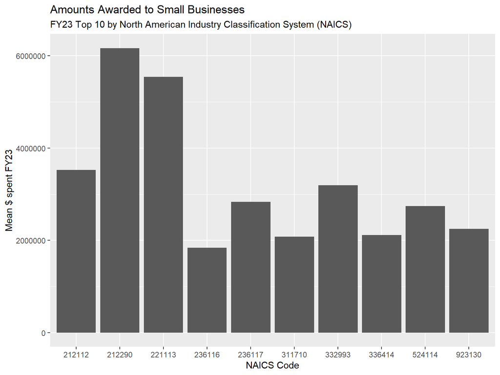

```r
collect(table_fy23 %>%
  filter(contracting_officers_determination_of_business_size == 'SMALL BUSINESS')) %>%
  mutate(naics_str = sprintf('%d',naics_code)) %>%
  group_by(naics_str) %>%
  mutate(naics_ob = mean(federal_action_obligation, na.rm = T)) %>%
  summarise(naics_ob_max = max(naics_ob, na.rm = T)) %>%
  arrange(desc(naics_ob_max)) %>%
  head(n=10) %>%
  ggplot() +
  geom_col(aes(x=naics_str, y=naics_ob_max)) +
  labs(title = "Amounts Awarded to Small Businesses",
       subtitle = 'FY23 Top 10 by North American Industry Classification System (NAICS)',
       x = "NAICS Code",
       y = "Mean $ spent FY23")
```

212112: ? 212290: Other Metal Ore Mining 221113: Nuclear Electric Power Generation 236116: New Multifamily Housing Construction (except For-Sale Builders) 236117: New Housing For-Sale Builders 311710: Seafood Product Preparation and Packaging 332993: Ammunition (except Small Arms) Manufacturing 336414: Guided Missile and Space Vehicle Manufacturing 524114: Direct Health and Medical Insurance Carriers 923130: Administration of Human Resource Programs (except Education, Public Health, and Veterans’ Affairs Programs)

# Contracts by PSC Top 10

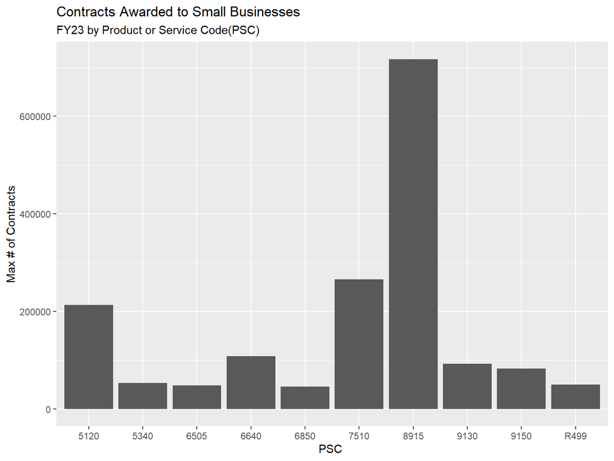

```r
collect(table_fy23 %>%
  filter(contracting_officers_determination_of_business_size == 'SMALL BUSINESS')) %>%
  #mutate(psc_str = sprintf('%d',product_or_service_code)) %>%
  group_by(product_or_service_code) %>%
  add_count(contract_transaction_unique_key) %>%
  mutate(contract_counts = sum(n, na.rm = T)) %>%
  summarise(contracts = max(contract_counts, na.rm = T)) %>%
  arrange(desc(contracts)) %>%
  head(n=10) %>%
  ggplot() +
  geom_col(aes(x=product_or_service_code, y=contracts)) +
  labs(title = "Contracts Awarded to Small Businesses",
       subtitle = 'FY23 by Product or Service Code(PSC)',
       x = "PSC ",
       y = "Max # of Contracts")
```

5120: hand tools, nonedged, nonpowered 5340: hardware, commercial 6505: Drugs and Pharmaceutical Products 6640: laboratory equipment and supplies 6850: miscellaneous chemical specialties 7510: office supplies 8915: fruits and vegetables 9130: liquid propellants and fuels, petroleum base 9150: oils and greases: cutting, lubricating, and hydraulic R499: support- professional: other

# Mean Amount by PSC Top 10

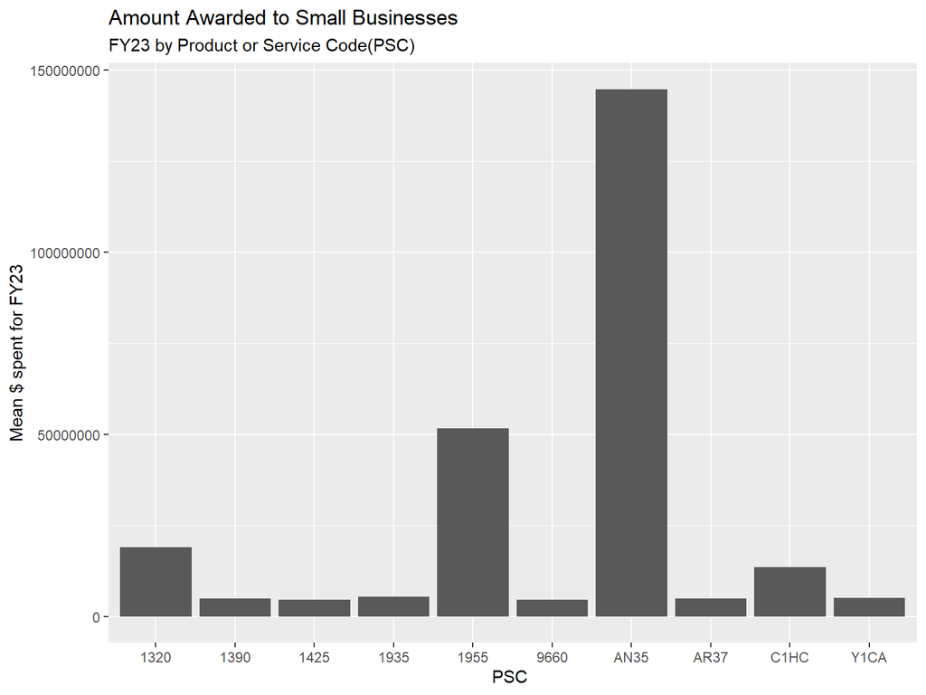

```r
collect(table_fy23 %>%
  filter(contracting_officers_determination_of_business_size == 'SMALL BUSINESS')) %>%
  group_by(product_or_service_code) %>%
  mutate(psc_ob = mean(federal_action_obligation, na.rm = T)) %>%
  summarise(psc_ob_max = max(psc_ob, na.rm = T)) %>%
  arrange(desc(psc_ob_max)) %>%
  head(n=10) %>%
  ggplot() +
  geom_col(aes(x=product_or_service_code, y=psc_ob_max)) +
  labs(title = "Amount Awarded to Small Businesses",
       subtitle = 'FY23 by Product or Service Code(PSC)',
       x = "PSC ",
       y = "Mean $ spent for FY23")
```

1320: ammunition, over 125mm 1390: fuzes and primers 1425: guided missile systems, complete 1935: barges and lighters, special purpose 1955: dredges 9660: precious metals primary forms AN35: health r&d svcs; consumer & occupational health & safety; r&d facilities & maj equip AR37: ? C1HC: architect and engineering- construction: govt-owned ctr-operated (goco) environmental laboratories Y1CA: construction of schools